# MThambeliyagodage_Data605_W5_Assign5

## Problem set 1

Choose independently two numbers B and C at random from the interval [0, 1] with uniform density. Prove that B and C are proper probability distributions. Note that the point (B,C) is then chosen at random in the unit square. Find the probability that:

Since $B$ and $C$ are selected with uniform density, let us define the density function as $f(x) = \begin{cases} 1, & \mbox{if } 0\leq x\leq 1, \\ 0, & \mbox{otherwise. }\end{cases}$

Then $P(0\leq X\leq 1) = \int_{0}^{1}{f(x)dx} = 1$.

The value of $f(x)$ is greater than or equal to $0$ for all $x$ and total area under the density function is equal to $1$. As such this is a proper probability distribution that satisfies both $B$ and $C$.

Now, consider a unit square with a randomly chosen point $(B,C)$.

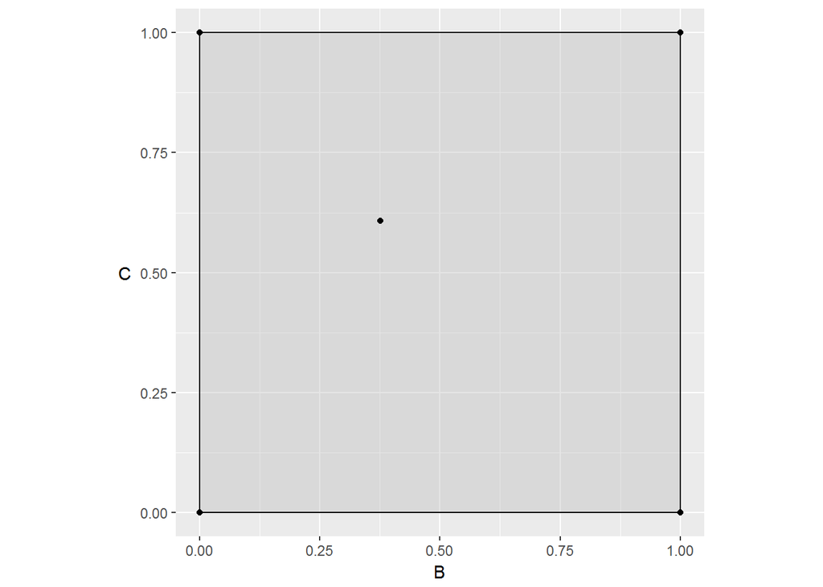

```r
library(ggplot2)
ggplot()+
  geom_rect(aes(xmin=0, xmax=1, ymin=0,ymax=1), fill="grey", alpha=0.4, color="black")+
  geom_point(aes(c(1,0,0,1,runif(1,0,1)),c(1,0,1,0,runif(1,0,1))))+
  xlim(0,1)+ylim(0,1)+coord_fixed()+
  xlab("B")+ylab("C")+
  theme(axis.title.y = element_text(angle = 0, vjust=0.5))
```

### (A) B + C < 1/2

Consider $x+y=0.5$, where $x$ represents $B$ and $y$ represents $C$. Then $y = 0.5-x$. If we plot this line in the unit square, then the area under the line will be all values of $B$ and $C$ such that $B+C<0.5$ and the area will equal the probability $P(B+C<0.5)$.

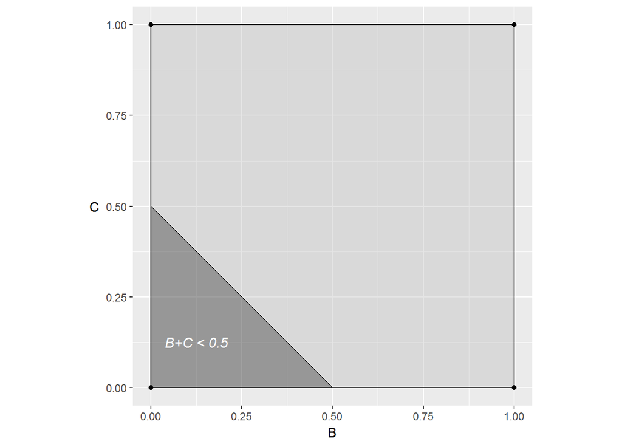

```r
x <- seq(from=0,to=0.5,length.out=1000)
y <- 0.5-x

# Define polygon for under the curve shading
shade <- rbind(c(0,0), data.frame(x,y))

ggplot()+
  geom_rect(aes(xmin=0, xmax=1, ymin=0,ymax=1), fill="grey", alpha=0.4, color="black")+
  geom_point(aes(c(1,0,0,1),c(1,0,1,0)))+
  xlim(0,1)+ylim(0,1)+coord_fixed()+
  xlab("B")+ylab("C")+
  theme(axis.title.y = element_text(angle = 0, vjust=0.5))+
  geom_line(aes(x,y))+
  geom_polygon(aes(shade$x,shade$y), fill="black", alpha=0.3)+
  geom_text(aes(0.125,0.125), label="B+C < 0.5", size=4, color="white", fontface="italic")
```

$P(B+C<0.5) = \frac{0.5^2}{2} = \frac{0.25}{2} = 0.125$

### (B) BC < 1/2

Consider $xy=0.5$, where $x$ represents $B$ and $y$ represents $C$. Then $y = \frac{0.5}{x} = \frac{1}{2x}$. If we plot this line in the unit square, then the area under the line will be all values of $B$ and $C$ such that $BC<0.5$ and the area will equal the probability $P(BC<0.5)$.

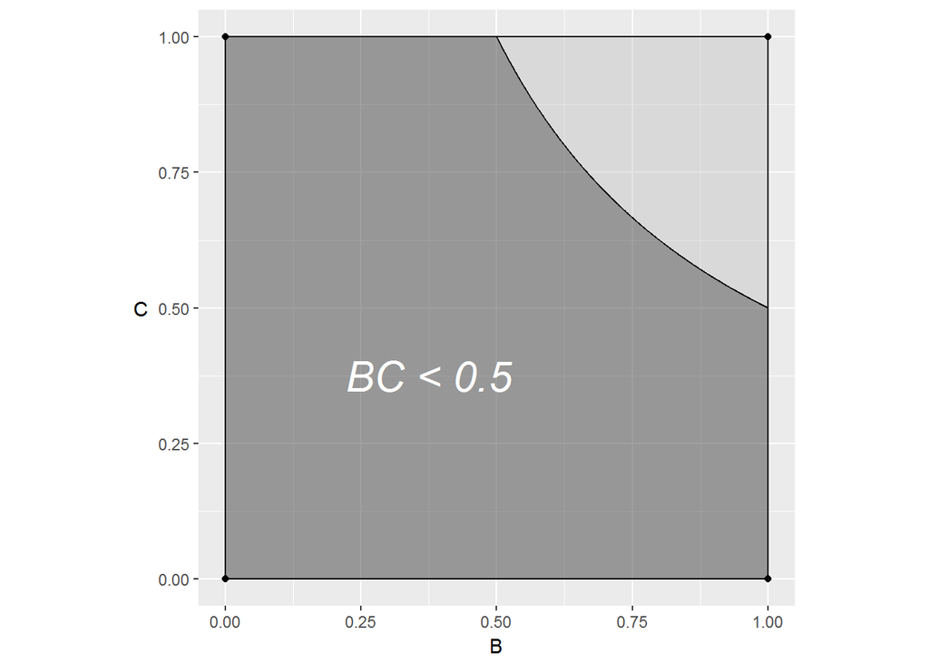

```r
x <- seq(from=0.5,to=1,length.out=1000)
y <- 1/(2*x)

# Define polygon for under the curve shading
shade <- rbind(c(0,0), c(0,1), c(0.5,1), data.frame(x,y), c(1, 0))

ggplot()+
  geom_rect(aes(xmin=0, xmax=1, ymin=0,ymax=1), fill="grey", alpha=0.4, color="black")+
  geom_point(aes(c(1,0,0,1),c(1,0,1,0)))+
  xlim(0,1)+ylim(0,1)+coord_fixed()+
  xlab("B")+ylab("C")+
  theme(axis.title.y = element_text(angle = 0, vjust=0.5))+
  geom_line(aes(x,y))+
  geom_polygon(aes(shade$x,shade$y), fill="black", alpha=0.3)+
  geom_text(aes(0.375,0.375), label="BC < 0.5", size=8, color="white", fontface="italic")
```

We can integrate to get the area under the curve and add $0.5$ of the left half of the unit square.

$P(BC<0.5) = 0.5 + \int_{0.5}^{1}{\frac{1}{2x}dx} = 0.5+0.346574 = 0.846574$

### (C) |B-C| < 1/2

Similarly to the above consider two lines - $x-y=0.5$ and $x-y=-0.5$.

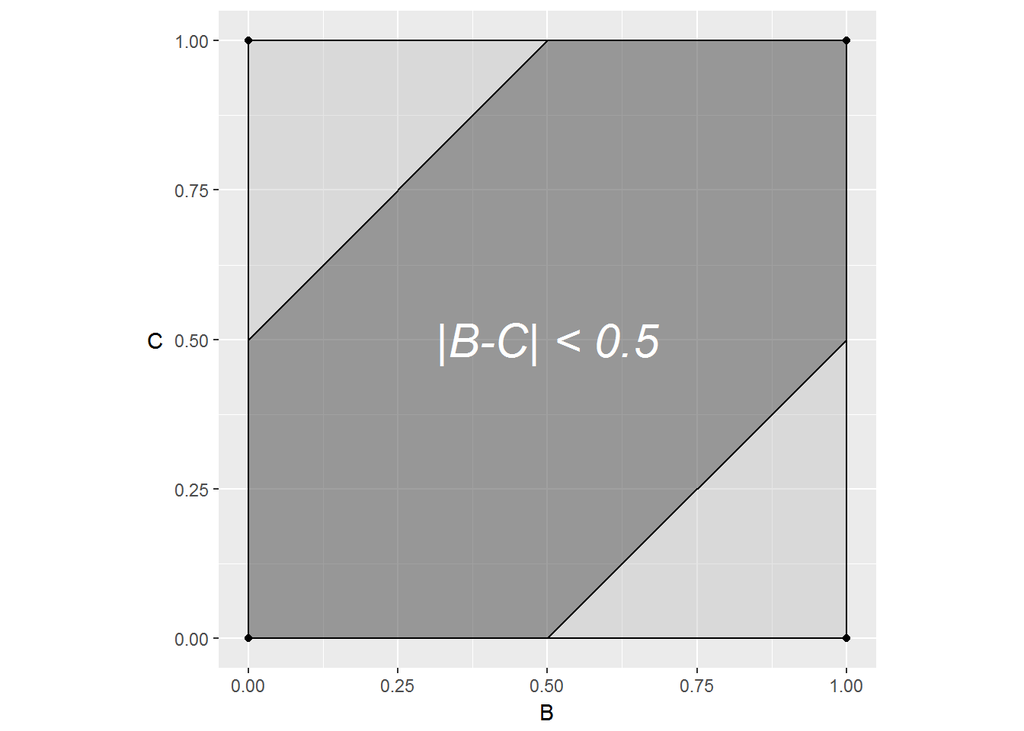

```r
x1 <- seq(from=0.5,to=1,length.out=2)
x2 <- seq(from=0,to=0.5,length.out=2)
y1 <- x1-0.5
y2 <- x2+0.5

# Define polygon for under the curve shading
shade <- cbind(c(0,0,0.5,1,1,0.5), c(0,0.5,1,1,0.5,0))

ggplot()+
  geom_rect(aes(xmin=0, xmax=1, ymin=0,ymax=1), fill="grey", alpha=0.4, color="black")+
  geom_point(aes(c(1,0,0,1),c(1,0,1,0)))+
  xlim(0,1)+ylim(0,1)+coord_fixed()+
  xlab("B")+ylab("C")+
  theme(axis.title.y = element_text(angle = 0, vjust=0.5))+
  geom_line(aes(x1,y1))+
  geom_line(aes(x2,y2))+
  geom_polygon(aes(shade[,1],shade[,2]), fill="black", alpha=0.3)+
  geom_text(aes(0.5,0.5), label="|B-C| < 0.5", size=8, color="white", fontface="italic")
```

We can easily see that the probability of the event is $1$ minus two triangles similar to part (a).

$P(|B-C|<0.5) = 1 - 2\times 0.125 = 0.75$

### (D) max{B,C} < 1/2

Any combination of $B$ and $C$ such that $B<0.5$ and $C<0.5$, will satisfy $max\{B,C\}<0.5$. If $B>0.5$, then either $B>C$ and $max\{B,C\}=B>0.5$ or $0.5<B<C$ and $max\{B,C\}=C>0.5$. Similarly for $C>0.5$.

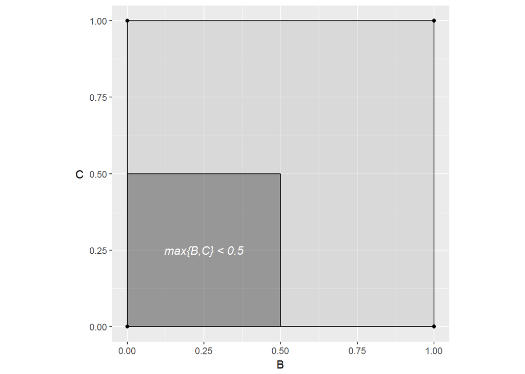

```r
# Define polygon for under the curve shading
shade <- cbind(c(0,0,0.5,0.5), c(0,0.5,0.5,0))

ggplot()+
  geom_rect(aes(xmin=0, xmax=1, ymin=0,ymax=1), fill="grey", alpha=0.4, color="black")+
  geom_point(aes(c(1,0,0,1),c(1,0,1,0)))+
  xlim(0,1)+ylim(0,1)+coord_fixed()+
  xlab("B")+ylab("C")+
  geom_line(aes(c(0,0.5),c(0.5,0.5)))+
  geom_line(aes(c(0.5,0.5),c(0,0.5)))+
  theme(axis.title.y = element_text(angle = 0, vjust=0.5))+
  geom_polygon(aes(shade[,1],shade[,2]), fill="black", alpha=0.3)+
  geom_text(aes(0.25,0.25), label="max{B,C} < 0.5", size=4, color="white", fontface="italic")
```

$P(max\{B,C\} < 0.5) = 0.25$

### (E) min{B,C} < 1/2

Any combination of $B$ and $C$ such that $B<0.5$ or $C<0.5$, will satisfy $min\{B,C\}<0.5$. It is only if both $B$ and $C$ are greater than $0.5$, then $min\{B,C\}>0.5$.

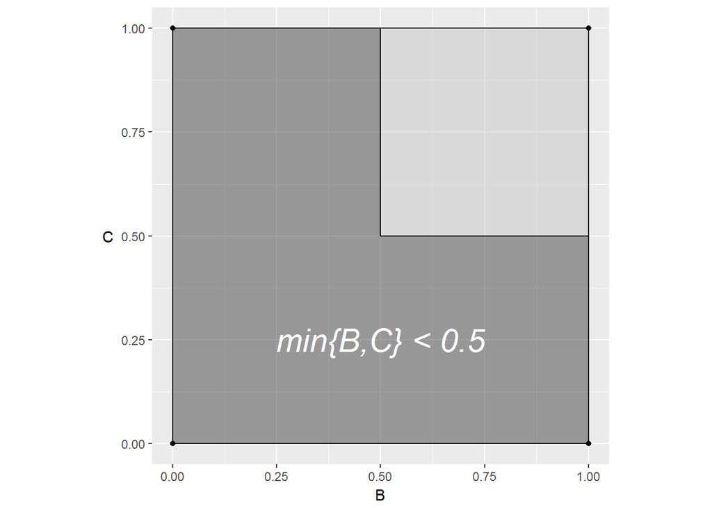

```r
# Define polygon for under the curve shading
shade <- cbind(c(0,0,0.5,0.5,1,1), c(0,1,1,0.5,0.5,0))

ggplot()+
  geom_rect(aes(xmin=0, xmax=1, ymin=0,ymax=1), fill="grey", alpha=0.4, color="black")+
  geom_point(aes(c(1,0,0,1),c(1,0,1,0)))+
  xlim(0,1)+ylim(0,1)+coord_fixed()+
  xlab("B")+ylab("C")+
  geom_line(aes(c(0.5,0.5),c(0.5,1)))+
  geom_line(aes(c(0.5,1),c(0.5,0.5)))+
  theme(axis.title.y = element_text(angle = 0, vjust=0.5))+
  geom_polygon(aes(shade[,1],shade[,2]), fill="black", alpha=0.3)+
  geom_text(aes(0.5,0.25), label="min{B,C} < 0.5", size=8, color="white", fontface="italic")
```

$P(min\{B,C\} < 0.5) = 0.75$

### Answer

1. $P(B + C < 1/2)=0.125$
2. $P(BC < 1/2)=0.846574$
3. $P(|B-C| < 1/2)=0.75$
4. $P(max\{B,C\} < 1/2)=0.25$
5. $P(min\{B,C\} < 1/2)=0.75$

#### Simulation

Double-check results via simulation. Modified from code posted on BlackBoard.

```r
n<-1000000
B<-runif(n,0,1)
C<-runif(n,0,1)

partA<-((B+C)<0.5)

partB<-((B*C)<0.5)

partC<-(abs(B-C)<0.5)

partD<-rep(0, n)
partE<-rep(0, n)
for (i in 1:n) {
  partD[i]<-max(B[i],C[i])
  partE[i]<-min(B[i],C[i])
}
partD<-(partD<0.5)
partE<-(partE<0.5)

simulation <- cbind(c("B+C<0.5", "BC<0.5", "|B-C|<0.5", "max(B,C)<0.5", "min(B,C)<0.5"),
                    c(sum(partA)/n,sum(partB)/n,sum(partC)/n,sum(partD)/n,sum(partE)/n)
                    )
colnames(simulation) <- c("Event", "Probability")
rownames(simulation) <- c("a","b","c","d","e")
simulation
```

```
##   Event          Probability
## a "B+C<0.5"      "0.124846"
## b "BC<0.5"       "0.847394"
## c "|B-C|<0.5"    "0.748808"
## d "max(B,C)<0.5" "0.249424"
## e "min(B,C)<0.5" "0.750805"
```